# Biostat 200C Homework 2

Due Apr 25 @ 11:59PM

Published

April 14, 2026

To submit homework, please upload both Rmd and html files to Bruinlearn by the deadline.

## 1 Q1. CFR of COVID-19 (90pts)

Of primary interest to public is the risk of dying from COVID-19. A commonly used measure is case fatality rate/ratio/risk (CFR), which is defined as
$$\frac{\text{number of deaths from disease}}{\text{number of diagnosed cases of disease}}.$$
Apparently CFR is not a fixed constant; it changes with time, location, and other factors. Also CFR is different from the infection fatality rate (IFR), the probability that someone infected with COVID-19 dies from it.

In this exercise, we use logistic regression to study how US county-level CFR changes according to demographic information and some health-, education-, and economy-indicators.

### 1.1 Data sources

- `04-04-2020.csv.gz`: The data on COVID-19 confirmed cases and deaths on 2020-04-04 is retrieved from the [Johns Hopkins COVID-19 data repository](https://github.com/CSSEGISandData/COVID-19). It was downloaded from this [link](https://github.com/CSSEGISandData/COVID-19) (commit 0174f38). This repository has been archived by the owner on Mar 10, 2023. It is now read-only. You can download data from box: https://ucla.box.com/s/brb3vz4nwoq8pjkcutxncymqw583d39l
- `us-county-health-rankings-2020.csv.gz`: The 2020 County Health Ranking Data was released by [County Health Rankings](https://www.countyhealthrankings.org). The data was downloaded from the [Kaggle Uncover COVID-19 Challenge](https://www.kaggle.com/roche-data-science-coalition/uncover) (version 1). You can download data from box: https://ucla.box.com/s/brb3vz4nwoq8pjkcutxncymqw583d39l

### 1.2 Sample code for data preparation

Load the `tidyverse` package for data manipulation and visualization.

```r
# tidyverse of data manipulation and visualization
library(tidyverse)
```

Read in the data of COVID-19 cases reported on 2020-04-04.

```r
county_count <- read_csv("./datasets/04-04-2020.csv.gz") %>%
  # cast fips into dbl for use as a key for joining tables
  mutate(FIPS = as.numeric(FIPS)) %>%
  filter(Country_Region == "US") %>%
  print(width = Inf)
```

```
# A tibble: 2,421 × 12
    FIPS Admin2    Province_State Country_Region Last_Update           Lat
   <dbl> <chr>     <chr>          <chr>          <dttm>              <dbl>
 1 45001 Abbeville South Carolina US             2020-04-04 23:34:21  34.2
 2 22001 Acadia    Louisiana      US             2020-04-04 23:34:21  30.3
 3 51001 Accomack  Virginia       US             2020-04-04 23:34:21  37.8
 4 16001 Ada       Idaho          US             2020-04-04 23:34:21  43.5
 5 19001 Adair     Iowa           US             2020-04-04 23:34:21  41.3
 6 21001 Adair     Kentucky       US             2020-04-04 23:34:21  37.1
 7 29001 Adair     Missouri       US             2020-04-04 23:34:21  40.2
 8 40001 Adair     Oklahoma       US             2020-04-04 23:34:21  35.9
 9  8001 Adams     Colorado       US             2020-04-04 23:34:21  39.9
10 16003 Adams     Idaho          US             2020-04-04 23:34:21  44.9
    Long_ Confirmed Deaths Recovered Active Combined_Key
    <dbl>     <dbl>  <dbl>     <dbl>  <dbl> <chr>
 1  -82.5         6      0         0      0 Abbeville, South Carolina, US
 2  -92.4        65      2         0      0 Acadia, Louisiana, US
 3  -75.6         8      0         0      0 Accomack, Virginia, US
 4 -116.        360      3         0      0 Ada, Idaho, US
 5  -94.5         1      0         0      0 Adair, Iowa, US
 6  -85.3         3      0         0      0 Adair, Kentucky, US
 7  -92.6        10      0         0      0 Adair, Missouri, US
 8  -94.7        14      0         0      0 Adair, Oklahoma, US
 9 -104.        294      9         0      0 Adams, Colorado, US
10 -116.          1      0         0      0 Adams, Idaho, US
# ℹ 2,411 more rows
```

Standardize the variable names by changing them to lower case.

```r
names(county_count) <- str_to_lower(names(county_count))
```

Sanity check by displaying the unique US states and territories:

```r
county_count %>%
  select(province_state) %>%
  distinct() %>%
  arrange(province_state) %>%
  print(n = Inf)
```

```
# A tibble: 58 × 1
   province_state
   <chr>
 1 Alabama
 2 Alaska
 3 Arizona
 4 Arkansas
 5 California
 6 Colorado
 7 Connecticut
 8 Delaware
 9 Diamond Princess
10 District of Columbia
11 Florida
12 Georgia
```

[output cut: 46 more lines]

We want to exclude entries from `Diamond Princess`, `Grand Princess`, `Guam`, `Northern Mariana Islands`, `Puerto Rico`, `Recovered`, and `Virgin Islands`, and only consider counties from 50 states and DC.

```r
county_count <- county_count %>%
  filter(!(province_state %in% c("Diamond Princess", "Grand Princess",
                                 "Recovered", "Guam", "Northern Mariana Islands",
                                 "Puerto Rico", "Virgin Islands"))) %>%
  print(width = Inf)
```

```
# A tibble: 2,413 × 12
    fips admin2    province_state country_region last_update           lat
   <dbl> <chr>     <chr>          <chr>          <dttm>              <dbl>
 1 45001 Abbeville South Carolina US             2020-04-04 23:34:21  34.2
 2 22001 Acadia    Louisiana      US             2020-04-04 23:34:21  30.3
 3 51001 Accomack  Virginia       US             2020-04-04 23:34:21  37.8
 4 16001 Ada       Idaho          US             2020-04-04 23:34:21  43.5
 5 19001 Adair     Iowa           US             2020-04-04 23:34:21  41.3
 6 21001 Adair     Kentucky       US             2020-04-04 23:34:21  37.1
 7 29001 Adair     Missouri       US             2020-04-04 23:34:21  40.2
 8 40001 Adair     Oklahoma       US             2020-04-04 23:34:21  35.9
 9  8001 Adams     Colorado       US             2020-04-04 23:34:21  39.9
10 16003 Adams     Idaho          US             2020-04-04 23:34:21  44.9
    long_ confirmed deaths recovered active combined_key
    <dbl>     <dbl>  <dbl>     <dbl>  <dbl> <chr>
 1  -82.5         6      0         0      0 Abbeville, South Carolina, US
 2  -92.4        65      2         0      0 Acadia, Louisiana, US
 3  -75.6         8      0         0      0 Accomack, Virginia, US
 4 -116.        360      3         0      0 Ada, Idaho, US
 5  -94.5         1      0         0      0 Adair, Iowa, US
 6  -85.3         3      0         0      0 Adair, Kentucky, US
 7  -92.6        10      0         0      0 Adair, Missouri, US
 8  -94.7        14      0         0      0 Adair, Oklahoma, US
 9 -104.        294      9         0      0 Adams, Colorado, US
10 -116.          1      0         0      0 Adams, Idaho, US
# ℹ 2,403 more rows
```

Graphical summarize the COVID-19 confirmed cases and deaths on 2020-04-04 by state.

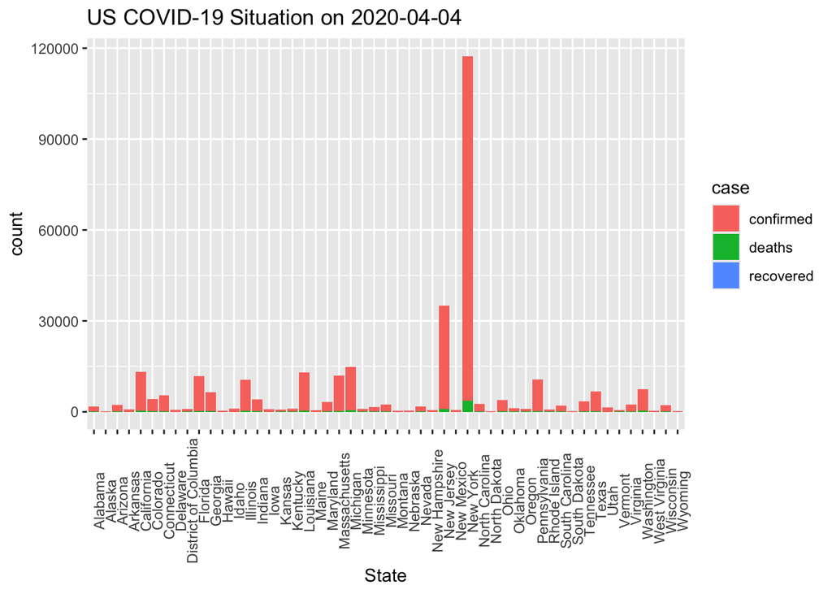

```r
county_count %>%
  # turn into long format for easy plotting
  pivot_longer(confirmed:recovered,
               names_to = "case",
               values_to = "count") %>%
  group_by(province_state) %>%
  ggplot() +
  geom_col(mapping = aes(x = province_state, y = `count`, fill = `case`)) +
  # scale_y_log10() +
  labs(title = "US COVID-19 Situation on 2020-04-04", x = "State") +
  theme(axis.text.x = element_text(angle = 90))
```

Read in the 2020 county-level health ranking data.

```r
county_info <- read_csv("./datasets/us-county-health-rankings-2020.csv.gz") %>%
  filter(!is.na(county)) %>%
  # cast fips into dbl for use as a key for joining tables
  mutate(fips = as.numeric(fips)) %>%
  select(fips,
         state,
         county,
         percent_fair_or_poor_health,
         percent_smokers,
         percent_adults_with_obesity,
         # food_environment_index,
         percent_with_access_to_exercise_opportunities,
         percent_excessive_drinking,
         # teen_birth_rate,
         percent_uninsured,
         # primary_care_physicians_rate,
         # preventable_hospitalization_rate,
         # high_school_graduation_rate,
         percent_some_college,
         percent_unemployed,
         percent_children_in_poverty,
         # `80th_percentile_income`,
         # `20th_percentile_income`,
         percent_single_parent_households,
         # violent_crime_rate,
         percent_severe_housing_problems,
         overcrowding,
         # life_expectancy,
         # age_adjusted_death_rate,
         percent_adults_with_diabetes,
         # hiv_prevalence_rate,
         percent_food_insecure,
         # percent_limited_access_to_healthy_foods,
         percent_insufficient_sleep,
         percent_uninsured_2,
         median_household_income,
         average_traffic_volume_per_meter_of_major_roadways,
         percent_homeowners,
         # percent_severe_housing_cost_burden,
         population_2,
         percent_less_than_18_years_of_age,
         percent_65_and_over,
         percent_black,
         percent_asian,
         percent_hispanic,
         percent_female,
         percent_rural) %>%
  print(width = Inf)
```

```
# A tibble: 3,142 × 30
    fips state   county   percent_fair_or_poor_health percent_smokers
   <dbl> <chr>   <chr>                          <dbl>           <dbl>
 1  1001 Alabama Autauga                         20.9            18.1
 2  1003 Alabama Baldwin                         17.5            17.5
 3  1005 Alabama Barbour                         29.6            22.0
 4  1007 Alabama Bibb                            19.4            19.1
 5  1009 Alabama Blount                          21.7            19.2
 6  1011 Alabama Bullock                         31.0            22.9
 7  1013 Alabama Butler                          27.9            21.8
 8  1015 Alabama Calhoun                         23.1            20.6
 9  1017 Alabama Chambers                        24.0            19.4
10  1019 Alabama Cherokee                        20.7            17.5
   percent_adults_with_obesity percent_with_access_to_exercise_opportunities
                         <dbl>                                         <dbl>
```

[output cut: 107 more lines]

For stability in estimating CFR, we restrict to counties with $\ge 5$ confirmed cases.

```r
county_count <- county_count %>%
  filter(confirmed >= 5)
```

We join the COVID-19 count data and county-level information using FIPS (Federal Information Processing System) as key.

```r
county_data <- county_count %>%
  left_join(county_info, by = "fips") %>%
  print(width = Inf)
```

```
# A tibble: 1,466 × 41
    fips admin2    province_state country_region last_update           lat
   <dbl> <chr>     <chr>          <chr>          <dttm>              <dbl>
 1 45001 Abbeville South Carolina US             2020-04-04 23:34:21  34.2
 2 22001 Acadia    Louisiana      US             2020-04-04 23:34:21  30.3
 3 51001 Accomack  Virginia       US             2020-04-04 23:34:21  37.8
 4 16001 Ada       Idaho          US             2020-04-04 23:34:21  43.5
 5 29001 Adair     Missouri       US             2020-04-04 23:34:21  40.2
 6 40001 Adair     Oklahoma       US             2020-04-04 23:34:21  35.9
 7  8001 Adams     Colorado       US             2020-04-04 23:34:21  39.9
 8 28001 Adams     Mississippi    US             2020-04-04 23:34:21  31.5
 9 31001 Adams     Nebraska       US             2020-04-04 23:34:21  40.5
10 42001 Adams     Pennsylvania   US             2020-04-04 23:34:21  39.9
    long_ confirmed deaths recovered active combined_key
    <dbl>     <dbl>  <dbl>     <dbl>  <dbl> <chr>
```

[output cut: 131 more lines]

Numerical summaries of each variable:

```r
summary(county_data)
```

```
      fips          admin2          province_state     country_region
 Min.   : 1001   Length:1466        Length:1466        Length:1466
 1st Qu.:18003   Class :character   Class :character   Class :character
 Median :29029   Mode  :character   Mode  :character   Mode  :character
 Mean   :30076
 3rd Qu.:42077
 Max.   :90053
 NA's   :13
  last_update                       lat            long_
 Min.   :2020-04-04 23:34:21   Min.   :19.60   Min.   :-159.60
 1st Qu.:2020-04-04 23:34:21   1st Qu.:33.96   1st Qu.: -94.56
 Median :2020-04-04 23:34:21   Median :38.02   Median : -86.48
 Mean   :2020-04-04 23:34:21   Mean   :37.71   Mean   : -89.73
 3rd Qu.:2020-04-04 23:34:21   3rd Qu.:41.38   3rd Qu.: -81.22
 Max.   :2020-04-04 23:34:21   Max.   :64.81   Max.   : -68.65
                               NA's   :19      NA's   :19
   confirmed           deaths           recovered     active
 Min.   :    5.0   Min.   :   0.000   Min.   :0   Min.   :0
 1st Qu.:    9.0   1st Qu.:   0.000   1st Qu.:0   1st Qu.:0
 Median :   20.0   Median :   0.000   Median :0   Median :0
 Mean   :  208.8   Mean   :   4.842   Mean   :0   Mean   :0
 3rd Qu.:   68.0   3rd Qu.:   2.000   3rd Qu.:0   3rd Qu.:0
 Max.   :63306.0   Max.   :1905.000   Max.   :0   Max.   :0

 combined_key          state              county
 Length:1466        Length:1466        Length:1466
 Class :character   Class :character   Class :character
 Mode  :character   Mode  :character   Mode  :character




 percent_fair_or_poor_health percent_smokers  percent_adults_with_obesity
 Min.   : 8.121              Min.   : 5.909   Min.   :12.40
 1st Qu.:14.390              1st Qu.:14.899   1st Qu.:29.10
 Median :17.010              Median :17.147   Median :32.95
 Mean   :17.594              Mean   :17.153   Mean   :32.41
 3rd Qu.:20.377              3rd Qu.:19.365   3rd Qu.:36.20
 Max.   :38.887              Max.   :27.775   Max.   :51.00
 NA's   :28                  NA's   :28       NA's   :28
```

[output cut: 57 more lines]

```
 Min.   : 7.722      Min.   : 0.1286   Min.   : 0.06245   Min.   : 0.7952
 1st Qu.:14.927      1st Qu.: 1.6174   1st Qu.: 0.68249   1st Qu.: 2.9419
 Median :17.222      Median : 5.6397   Median : 1.23421   Median : 5.5939
 Mean   :17.516      Mean   :12.4178   Mean   : 2.40412   Mean   :10.0011
 3rd Qu.:19.598      3rd Qu.:17.5931   3rd Qu.: 2.67550   3rd Qu.:11.0564
 Max.   :57.587      Max.   :81.9544   Max.   :42.95231   Max.   :96.3596
 NA's   :28          NA's   :28        NA's   :28         NA's   :28
 percent_female  percent_rural
 Min.   :34.63   Min.   :  0.00
 1st Qu.:50.00   1st Qu.: 17.11
 Median :50.66   Median : 36.97
 Mean   :50.46   Mean   : 40.11
 3rd Qu.:51.35   3rd Qu.: 60.00
 Max.   :56.87   Max.   :100.00
 NA's   :28      NA's   :28
```

List rows in `county_data` that don’t have a match in `county_count`:

```r
county_data %>%
  filter(is.na(state) & is.na(county)) %>%
  print(n = Inf)
```

```
# A tibble: 28 × 41
    fips admin2   province_state country_region last_update           lat  long_
   <dbl> <chr>    <chr>          <chr>          <dttm>              <dbl>  <dbl>
 1    NA DeKalb   Tennessee      US             2020-04-04 23:34:21  36.0  -85.8
 2    NA DeSoto   Florida        US             2020-04-04 23:34:21  27.2  -81.8
 3    NA Dukes a… Massachusetts  US             2020-04-04 23:34:21  41.4  -70.7
 4    NA Fillmore Minnesota      US             2020-04-04 23:34:21  43.7  -92.1
 5    NA Kansas … Missouri       US             2020-04-04 23:34:21  39.1  -94.6
 6    NA LaSalle  Illinois       US             2020-04-04 23:34:21  41.3  -88.9
 7    NA Manassas Virginia       US             2020-04-04 23:34:21  38.7  -77.5
 8    NA McDuffie Georgia        US             2020-04-04 23:34:21  33.5  -82.5
 9    NA Out of … Michigan       US             2020-04-04 23:34:21  NA     NA
10    NA Out of … Tennessee      US             2020-04-04 23:34:21  NA     NA
11 90005 Unassig… Arkansas       US             2020-04-04 23:34:21  NA     NA
12 90008 Unassig… Colorado       US             2020-04-04 23:34:21  NA     NA
```

[output cut: 23 more lines]

We found there are some rows that miss `fips`.

```r
county_count %>%
  filter(is.na(fips)) %>%
  select(fips, admin2, province_state) %>%
  print(n = Inf)
```

```
# A tibble: 13 × 3
    fips admin2              province_state
   <dbl> <chr>               <chr>
 1    NA DeKalb              Tennessee
 2    NA DeSoto              Florida
 3    NA Dukes and Nantucket Massachusetts
 4    NA Fillmore            Minnesota
 5    NA Kansas City         Missouri
 6    NA LaSalle             Illinois
 7    NA Manassas            Virginia
 8    NA McDuffie            Georgia
 9    NA Out of MI           Michigan
10    NA Out of TN           Tennessee
11    NA Unassigned          Louisiana
12    NA Unassigned          Michigan
13    NA Weber               Utah
```

We need to (1) manually set the `fips` for some counties, (2) discard those `Unassigned`, `unassigned` or `Out of`, and (3) try to join with `county_info` again.

```r
county_data <- county_count %>%
  # manually set FIPS for some counties
  mutate(fips = ifelse(admin2 == "DeKalb" & province_state == "Tennessee", 47041, fips)) %>%
  mutate(fips = ifelse(admin2 == "DeSoto" & province_state == "Florida", 12027, fips)) %>%
  #mutate(fips = ifelse(admin2 == "Dona Ana" & province_state == "New Mexico", 35013, fips)) %>%
  mutate(fips = ifelse(admin2 == "Dukes and Nantucket" & province_state == "Massachusetts", 25019, fips)) %>%
  mutate(fips = ifelse(admin2 == "Fillmore" & province_state == "Minnesota", 27045, fips)) %>%
  #mutate(fips = ifelse(admin2 == "Harris" & province_state == "Texas", 48201, fips)) %>%
  #mutate(fips = ifelse(admin2 == "Kenai Peninsula" & province_state == "Alaska", 2122, fips)) %>%
  mutate(fips = ifelse(admin2 == "LaSalle" & province_state == "Illinois", 17099, fips)) %>%
  #mutate(fips = ifelse(admin2 == "LaSalle" & province_state == "Louisiana", 22059, fips)) %>%
  #mutate(fips = ifelse(admin2 == "Lac qui Parle" & province_state == "Minnesota", 27073, fips)) %>%
  mutate(fips = ifelse(admin2 == "Manassas" & province_state == "Virginia", 51683, fips)) %>%
  #mutate(fips = ifelse(admin2 == "Matanuska-Susitna" & province_state == "Alaska", 2170, fips)) %>%
  mutate(fips = ifelse(admin2 == "McDuffie" & province_state == "Georgia", 13189, fips)) %>%
  #mutate(fips = ifelse(admin2 == "McIntosh" & province_state == "Georgia", 13191, fips)) %>%
  #mutate(fips = ifelse(admin2 == "McKean" & province_state == "Pennsylvania", 42083, fips)) %>%
  mutate(fips = ifelse(admin2 == "Weber" & province_state == "Utah", 49057, fips)) %>%
  filter(!(is.na(fips) | str_detect(admin2, "Out of") | str_detect(admin2, "Unassigned"))) %>%
  left_join(county_info, by = "fips") %>%
  print(width = Inf)
```

```
# A tibble: 1,446 × 41
    fips admin2    province_state country_region last_update           lat
   <dbl> <chr>     <chr>          <chr>          <dttm>              <dbl>
 1 45001 Abbeville South Carolina US             2020-04-04 23:34:21  34.2
 2 22001 Acadia    Louisiana      US             2020-04-04 23:34:21  30.3
 3 51001 Accomack  Virginia       US             2020-04-04 23:34:21  37.8
 4 16001 Ada       Idaho          US             2020-04-04 23:34:21  43.5
 5 29001 Adair     Missouri       US             2020-04-04 23:34:21  40.2
 6 40001 Adair     Oklahoma       US             2020-04-04 23:34:21  35.9
 7  8001 Adams     Colorado       US             2020-04-04 23:34:21  39.9
 8 28001 Adams     Mississippi    US             2020-04-04 23:34:21  31.5
 9 31001 Adams     Nebraska       US             2020-04-04 23:34:21  40.5
10 42001 Adams     Pennsylvania   US             2020-04-04 23:34:21  39.9
    long_ confirmed deaths recovered active combined_key
    <dbl>     <dbl>  <dbl>     <dbl>  <dbl> <chr>
```

[output cut: 131 more lines]

Summarize again

```r
summary(county_data)
```

```
      fips          admin2          province_state     country_region
 Min.   : 1001   Length:1446        Length:1446        Length:1446
 1st Qu.:17186   Class :character   Class :character   Class :character
 Median :28156   Mode  :character   Mode  :character   Mode  :character
 Mean   :29455
 3rd Qu.:42048
 Max.   :56039
  last_update                       lat            long_
 Min.   :2020-04-04 23:34:21   Min.   :19.60   Min.   :-159.60
 1st Qu.:2020-04-04 23:34:21   1st Qu.:33.96   1st Qu.: -94.52
 Median :2020-04-04 23:34:21   Median :38.02   Median : -86.48
 Mean   :2020-04-04 23:34:21   Mean   :37.71   Mean   : -89.73
 3rd Qu.:2020-04-04 23:34:21   3rd Qu.:41.39   3rd Qu.: -81.21
 Max.   :2020-04-04 23:34:21   Max.   :64.81   Max.   : -68.65
   confirmed           deaths           recovered     active
 Min.   :    5.0   Min.   :   0.000   Min.   :0   Min.   :0
 1st Qu.:    9.0   1st Qu.:   0.000   1st Qu.:0   1st Qu.:0
 Median :   20.0   Median :   0.000   Median :0   Median :0
 Mean   :  207.2   Mean   :   4.854   Mean   :0   Mean   :0
 3rd Qu.:   66.0   3rd Qu.:   2.000   3rd Qu.:0   3rd Qu.:0
 Max.   :63306.0   Max.   :1905.000   Max.   :0   Max.   :0
 combined_key          state              county
 Length:1446        Length:1446        Length:1446
 Class :character   Class :character   Class :character
 Mode  :character   Mode  :character   Mode  :character



 percent_fair_or_poor_health percent_smokers  percent_adults_with_obesity
 Min.   : 8.121              Min.   : 5.909   Min.   :12.40
 1st Qu.:14.390              1st Qu.:14.899   1st Qu.:29.10
 Median :17.010              Median :17.143   Median :32.90
 Mean   :17.594              Mean   :17.151   Mean   :32.39
 3rd Qu.:20.398              3rd Qu.:19.365   3rd Qu.:36.20
 Max.   :38.887              Max.   :27.775   Max.   :51.00
 percent_with_access_to_exercise_opportunities percent_excessive_drinking
 Min.   :  0.00                                Min.   : 7.81
 1st Qu.: 59.95                                1st Qu.:15.68
 Median : 74.71                                Median :18.03
 Mean   : 71.15                                Mean   :17.91
```

[output cut: 43 more lines]

```
 Max.   :89.76      Max.   :10105518   Max.   :35.447
 percent_65_and_over percent_black     percent_asian      percent_hispanic
 Min.   : 7.722      Min.   : 0.1286   Min.   : 0.06245   Min.   : 0.7952
 1st Qu.:14.913      1st Qu.: 1.6168   1st Qu.: 0.68228   1st Qu.: 2.9451
 Median :17.225      Median : 5.6397   Median : 1.22863   Median : 5.6100
 Mean   :17.512      Mean   :12.4056   Mean   : 2.40009   Mean   :10.0338
 3rd Qu.:19.598      3rd Qu.:17.4904   3rd Qu.: 2.66813   3rd Qu.:11.1199
 Max.   :57.587      Max.   :81.9544   Max.   :42.95231   Max.   :96.3596
 percent_female  percent_rural
 Min.   :34.63   Min.   :  0.00
 1st Qu.:50.00   1st Qu.: 17.11
 Median :50.65   Median : 36.97
 Mean   :50.46   Mean   : 40.12
 3rd Qu.:51.35   3rd Qu.: 60.04
 Max.   :56.87   Max.   :100.00
```

If there are variables with missing value for many counties, we go back and remove those variables from consideration.

Let’s create a final data frame for analysis.

```r
county_data <- county_data %>%
  mutate(state = as.factor(state)) %>%
  select(county, confirmed, deaths, state, percent_fair_or_poor_health:percent_rural)
summary(county_data)
```

```
    county            confirmed           deaths                    state
 Length:1446        Min.   :    5.0   Min.   :   0.000   Georgia       :  96
 Class :character   1st Qu.:    9.0   1st Qu.:   0.000   Texas         :  80
 Mode  :character   Median :   20.0   Median :   0.000   North Carolina:  63
                    Mean   :  207.2   Mean   :   4.854   Mississippi   :  61
                    3rd Qu.:   66.0   3rd Qu.:   2.000   Indiana       :  58
                    Max.   :63306.0   Max.   :1905.000   Ohio          :  57
                                                         (Other)       :1031
 percent_fair_or_poor_health percent_smokers  percent_adults_with_obesity
 Min.   : 8.121              Min.   : 5.909   Min.   :12.40
 1st Qu.:14.390              1st Qu.:14.899   1st Qu.:29.10
 Median :17.010              Median :17.143   Median :32.90
 Mean   :17.594              Mean   :17.151   Mean   :32.39
 3rd Qu.:20.398              3rd Qu.:19.365   3rd Qu.:36.20
 Max.   :38.887              Max.   :27.775   Max.   :51.00

 percent_with_access_to_exercise_opportunities percent_excessive_drinking
 Min.   :  0.00                                Min.   : 7.81
 1st Qu.: 59.95                                1st Qu.:15.68
 Median : 74.71                                Median :18.03
 Mean   : 71.15                                Mean   :17.91
 3rd Qu.: 85.97                                3rd Qu.:20.01
 Max.   :100.00                                Max.   :28.62

 percent_uninsured percent_some_college percent_unemployed
 Min.   : 2.263    Min.   :21.14        Min.   : 1.582
 1st Qu.: 6.754    1st Qu.:53.21        1st Qu.: 3.252
 Median : 9.937    Median :61.19        Median : 3.870
 Mean   :10.592    Mean   :60.83        Mean   : 4.071
 3rd Qu.:13.527    3rd Qu.:68.72        3rd Qu.: 4.690
 Max.   :31.208    Max.   :90.34        Max.   :18.092

 percent_children_in_poverty percent_single_parent_households
 Min.   : 2.50               Min.   : 9.43
 1st Qu.:12.82               1st Qu.:27.07
 Median :18.40               Median :32.96
 Mean   :19.46               Mean   :33.83
 3rd Qu.:24.50               3rd Qu.:38.93
 Max.   :55.00               Max.   :80.00

```

[output cut: 32 more lines]

```
 percent_65_and_over percent_black     percent_asian      percent_hispanic
 Min.   : 7.722      Min.   : 0.1286   Min.   : 0.06245   Min.   : 0.7952
 1st Qu.:14.913      1st Qu.: 1.6168   1st Qu.: 0.68228   1st Qu.: 2.9451
 Median :17.225      Median : 5.6397   Median : 1.22863   Median : 5.6100
 Mean   :17.512      Mean   :12.4056   Mean   : 2.40009   Mean   :10.0338
 3rd Qu.:19.598      3rd Qu.:17.4904   3rd Qu.: 2.66813   3rd Qu.:11.1199
 Max.   :57.587      Max.   :81.9544   Max.   :42.95231   Max.   :96.3596

 percent_female  percent_rural
 Min.   :34.63   Min.   :  0.00
 1st Qu.:50.00   1st Qu.: 17.11
 Median :50.65   Median : 36.97
 Mean   :50.46   Mean   : 40.12
 3rd Qu.:51.35   3rd Qu.: 60.04
 Max.   :56.87   Max.   :100.00
```

Display the 10 counties with highest CFR.

```r
county_data %>%
  mutate(cfr = deaths / confirmed) %>%
  select(county, state, confirmed, deaths, cfr) %>%
  arrange(desc(cfr)) %>%
  top_n(10)
```

```
# A tibble: 18 × 5
   county         state          confirmed deaths   cfr
   <chr>          <fct>              <dbl>  <dbl> <dbl>
 1 Emmet          Michigan               7      2 0.286
 2 Grand Traverse Michigan              12      3 0.25
 3 Toole          Montana               12      3 0.25
 4 Fayette        Indiana               14      3 0.214
 5 Concordia      Louisiana              5      1 0.2
 6 Harrison       Texas                  5      1 0.2
 7 Huntington     Indiana                5      1 0.2
 8 Isabella       Michigan              10      2 0.2
 9 McDuffie       Georgia                5      1 0.2
10 Navarro        Texas                  5      1 0.2
11 Orange         Indiana                5      1 0.2
12 Perry          Pennsylvania           5      1 0.2
13 Randolph       Indiana                5      1 0.2
14 Rockingham     North Carolina         5      1 0.2
15 Seneca         Ohio                   5      1 0.2
16 Toombs         Georgia                5      1 0.2
17 Vigo           Indiana               10      2 0.2
18 Washington     Alabama                5      1 0.2
```

Write final data into a csv file for future use.

```r
write_csv(county_data, "./datasets/covid19-county-data-20200404.csv.gz")
```

### 1.3 Note:

Given that the datasets were collected in the middle of the pandemic, what assumptions of CFR might be violated by defining CFR as `deaths/confirmed` from this data set?

Because COVID-19 pandemic was still ongoing in 2020, we should realize some critical assumptions for defining CFR are not met using this datasets.

1. Numbers of confirmed cases do not reflect the number of diagnosed people. This is mainly limited by the availability of testing.
2. Some confirmed cases may die later.

With acknowledgement of these severe limitations, we continue to use `deaths/confirmed` as a very rough proxy of CFR.

### 1.4 Q1.1 (5pts)

Read and run above code to generate a data frame `county_data` that includes county-level COVID-19 confirmed cases and deaths, demographic, and health related information.

### 1.5 Q1.2(5pts)

What assumptions of logistic regression may be violated by this data set?

### 1.6 Q1.3 (10pts)

Run a logistic regression, using variables `state`, …, `percent_rural` as predictors.

### 1.7 Q1.4 (10pts)

Interpret the regression coefficients of 3 significant predictors with p-value <0.05.

### 1.8 Q1.5 (10pts)

Apply analysis of deviance to (1) evaluate the goodness of fit of the model and (2) compare the model to the intercept-only model.

### 1.9 Q1.6 (10pts)

Perform analysis of deviance to evaluate the significance of each predictor. Display the 10 most significant predictors.

### 1.10 Q1.7 (5pts)

Construct confidence intervals of regression coefficients.

### 1.11 Q1.8 (5pts)

Plot the deviance residuals against the fitted values. Are there potential outliers?

### 1.12 Q1.9 (5pts)

Plot the half-normal plot. Are there potential outliers in predictor space?

### 1.13 Q1.10 (10pts)

Find the best sub-model using the AIC criterion.

### 1.14 Q1.11 (15pts)

Find the best sub-model using the lasso with cross validation.

## 2 Q2. Odds ratios (20pts)

Consider a $2 \times 2$ contingency table from a prospective study in which people who were or were not exposed to some pollutant are followed up and, after several years, categorized according to the presense or absence of a disease. Following table shows the probabilities for each cell. The odds of disease for either exposure group is $O_i = \pi_i / (1 - \pi_i)$, for $i = 1,2$, and so the odds ratio is
$$\phi = \frac{O_1}{O_2} = \frac{\pi_1(1 - \pi_2)}{\pi_2 (1 - \pi_1)}$$
is a measure of the relative likelihood of disease for the exposed and not exposed groups.

|  | Diseased | Not diseased |
| --- | --- | --- |
| Exposed | $\pi_1$ | $1 - \pi_1$ |
| Not exposed | $\pi_2$ | $1 - \pi_2$ |

### 2.1 Q2.1 (10pts)

For the simple logistic model
$$\pi_i = \frac{e^{\beta_i}}{1 + e^{\beta_i}},$$
show that if there is no difference between the exposed and not exposed groups (i.e., $\beta_1 = \beta_2$), then $\phi = 1$.

### 2.2 Q2.2(10pts)

Consider $J$ $2 \times 2$ tables, one for each level $x_j$ of a factor, such as age group, with $j=1,\ldots, J$. For the logistic model
$$\pi_{ij} = \frac{e^{\alpha_i + \beta_i x_j}}{1 + e^{\alpha_i + \beta_i x_j}}, \quad i = 1,2, \quad j= 1,\ldots, J.$$
Show that $\log \phi$ is constant over all tables if $\beta_1 = \beta_2$.

## 3 Q3. ELMR Chapter 4 Excercise 3 (30pts)